# Logistic Regression HW

Also there could be issues with multi-collinearity due to the high positive correlations between several of the predictors, I will remove the following:

- price_diff
- pct_disc_mm
- pct_disc_ch

[output not shown]

[output cut: 25 more lines]

[output not shown]

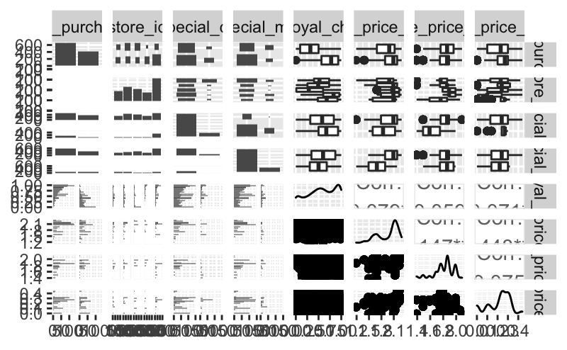

```r
# remove variables to combat multicollinearity & recheck pairs plot
juice_data_clean <- juice_data_clean %>%
  select(-c(price_diff, pct_disc_mm, pct_disc_ch))

ggpairs(juice_data_clean)
```

```r
# split data into test/train sets
n_data <- nrow(juice_data_clean)

test_index <- sample(1:n_data, size = n_data * 0.2)

juice_test <- slice(juice_data_clean, test_index)

juice_train <- slice(juice_data_clean, -test_index)
```

```r
# check test/train table ratios
juice_train %>%
  tabyl(mm_purchase)
```

```
 mm_purchase   n   percent
       FALSE 529 0.6179907
        TRUE 327 0.3820093
```

```r
juice_test %>%
  tabyl(mm_purchase)
```

```
 mm_purchase   n   percent
       FALSE 124 0.5794393
        TRUE  90 0.4205607
```

**Interpretation**

Ratios from the test and train data splits appear balanced, no issues here.

```r
# first logistic model
juice_log_model_1a <- glm(mm_purchase ~ loyal_ch + list_price_diff + store_id,
                          data = juice_train,
                          family = binomial(link = 'logit'))
```

```r
# summary of logistic model
summary(juice_log_model_1a)
```

[output not shown]

```r
# binomial anova using chi-square method to determine significance
anova(juice_log_model_1a, test = "Chisq")
```

```
Analysis of Deviance Table

Model: binomial, link: logit

Response: mm_purchase

Terms added sequentially (first to last)

                Df Deviance Resid. Df Resid. Dev  Pr(>Chi)
NULL                              855    1138.55
loyal_ch         1   393.81       854     744.74 < 2.2e-16 ***
list_price_diff  1    13.32       853     731.43 0.0002631 ***
store_id         4    15.97       849     715.45 0.0030581 **
---
Signif. codes:  0 ‘***’ 0.001 ‘**’ 0.01 ‘*’ 0.05 ‘.’ 0.1 ‘ ’ 1
```

**Interpretation**

This binomial ANOVA shows that each of the three current predictors are significant, since their respective p-values are all < 0.05.

```r
# add prediction to model on train set
juice_log_model_1a_pred <- juice_train %>%
  add_predictions(juice_log_model_1a, type = "response")

# create roc object from model with predictions
roc_juice_1a <- juice_log_model_1a_pred %>%
  roc(response = mm_purchase, predictor = pred)
# calculate area under the curve for this model
auc(roc_juice_1a)
```

```
Area under the curve: 0.882
```

**Interpretation**

```r
# reg subsets to help choose optimal number of variables
reg_summary <- summary(regsubsets(mm_purchase ~ ., data = juice_train,
                                  nvmax = 9))

summary(reg_summary)
```

[output not shown]

```r
# choose optimal number of predictors for logistic model through subsets plots
par(mfrow = c(2,2))

plot(reg_summary$rss, xlab = "Number of variables", ylab = "RSS",
     type = "l")

plot(reg_summary$adjr2, xlab = "Number of variables", ylab = "Adjusted RSq",
     type = "l")
```

```r
points(6, reg_summary$adjr2[6], col = "red", cex = 2, pch = 10)

plot(reg_summary$cp, xlab = "Number of variables", ylab = "Cp",
     type = "l")
```

```r
points(3, reg_summary$cp[3], col = "red", cex = 2, pch = 10)

plot(reg_summary$bic, xlab = "Number of variables", ylab = "BIC",
     type = "l")
```

[figure not shown]

```r
points(2, reg_summary$bic[2], col = "red", cex = 2, pch = 10)
```

```r
reg_summary$cp
```

```
[1] 69.944319 26.378610  7.428141  1.820306  2.194475  3.861729  5.532476  7.251836  9.007643
```

**Interpretation**

Used in conjunction, the above plots can give a good idea of the optimal number of predictors that should be included in my model.

We would like to minimise Residual Sum of Squares (RSS) and can see this decreases at a slower rate from 3 variables onwards.

We would like an adjusted r-squared as great as possible, this appears to shallow off after 3/4 variables. Meaning after 4 variables we are not getting much extra explaining power in our model.

CP is actually Mallows’ Cp statistic which estimates the size of the bias that is introduced into the predicted responses by having an underspecified model. It helps to show an over-fit model if it is too large. Ideally we want it to be small and close to the number of predictors in the model plus the constant. This is at it’s lowest at 4 variables, meaning a model with 4 could provide the most unbiased model.

```r
# which could/should be includded
summary(reg_summary$which)[3,]
```

[output not shown]

```r
juice_log_model_1b <- glm(mm_purchase ~ loyal_ch + list_price_diff + store_id
                          + sale_price_mm,
                          data = juice_train,
                          family = binomial(link = 'logit'))
```

```r
summary(juice_log_model_1b)
```

[output not shown]

```r
# add prediction to model on train set
juice_log_model_1b_pred <- juice_train %>%
  add_predictions(juice_log_model_1b, type = "response")

# create roc object from model with predictions
roc_juice_1b <- juice_log_model_1b_pred %>%
  roc(response = mm_purchase, predictor = pred)
# calculate area under the curve for this model
auc(roc_juice_1b)
```

```
Area under the curve: 0.8928
```

**Interpretation**

Adding `sale_price_mm` hasn’t done much for the ROC AUC, which is now 89.3%. Previously 88.2%

```r
juice_log_model_1a_pred  %>%
  mutate(model_pred = 1*(juice_log_model_1a$pred > 0.6) + 0,
                                 visit_binary = 1*(mm_purchase == "Yes") + 0)
```

[output not shown]

```r
print(paste("Accuracy is", 1 - classify_error))
```

[output not shown]

**Interpretation**